# PS2

# 1.2.1

## 1

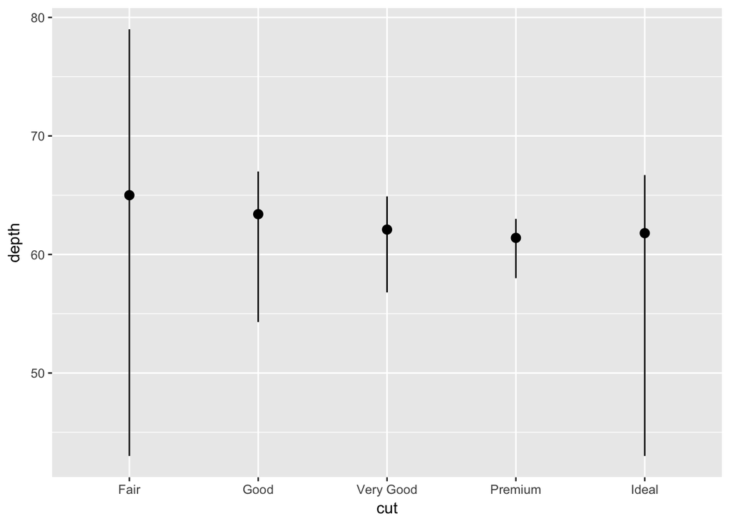

```r
ggplot(data = diamonds) +
  geom_pointrange(mapping = aes(x = cut, y = depth),
        stat = "summary",
        fun.ymin = min,
        fun.ymax = max,
        fun.y = median)
```

The default geom associated with stat_summary() is geom_pointrange. To rewrite, specify the pointrange() geom and use stat = “summary”. The ymin, ymax, and y = median are the same.

## 2

Geom_col creates columns from points and can be used to show values or statistics of the data. It can map values to the y aesthetic. Geom_bar displays bars whose height show the number of counts mapped to the x aesthetic.

## 3

geom_bar(stat = “identity”)

geom_bar(stat = “count”)

geom_bar(stat = “bin”)

geom_col(stat = “identity”)

The pairs all have a stat specification can be reversed. For example, we can use stat_count() with geom_bar as a parameter in stat_count().

# 4

Stat_smooth computes y (the predicted variable), ymin, ymax, and se. The parameters that control behavior is mapping, data, stat (“smooth”), position, method, formula, se, n, span, fullrange, level, method.args, na.rm, show.legend, and inherit.aes.

## 5

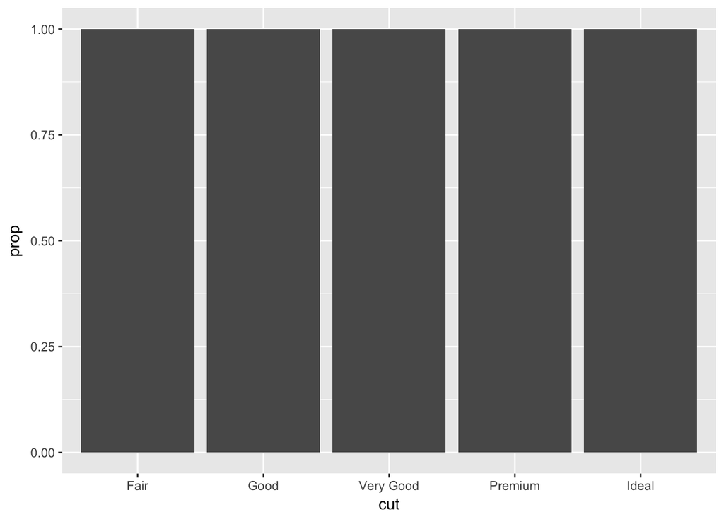

```r
ggplot(data = diamonds) +
  geom_bar(mapping = aes(x = cut, y = ..prop..))
```

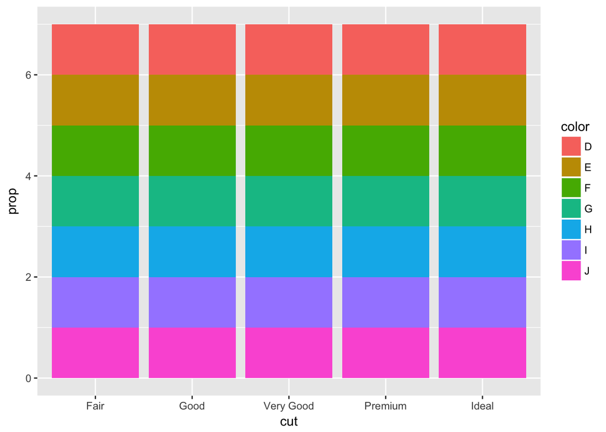

```r
ggplot(data = diamonds) +
  geom_bar(mapping = aes(x = cut, fill = color, y = ..prop..))
```

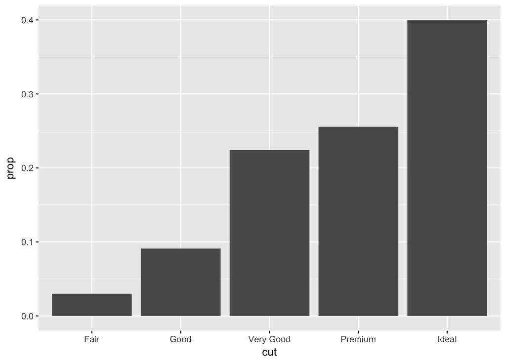

```r
ggplot(data = diamonds) +
  geom_bar(mapping = aes(x = cut, y = ..prop.., group = 1))
```

The specification of group = 1 is a dummy to indicate to group the x variables by each level of “cut” and compare each to the total of “cut”. Since we indicated proportions for the y aesthetic, we need to using this grouping (by each level of “cut” against total) so that the y axis is in proportions instead of frequency. The first two graphs above just show the proportion within each level so each level of “cut”" is 100% itself and not as a proportion of total “cut”.

# 1.3

## 1

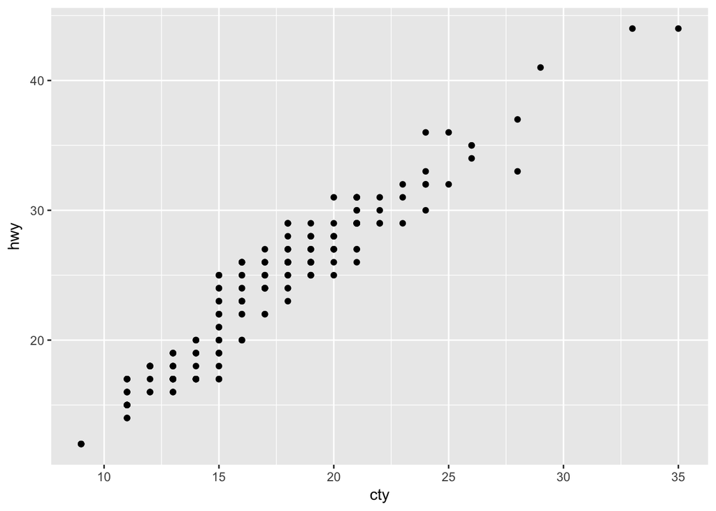

```r
ggplot(data = mpg, mapping = aes(x = cty, y = hwy)) + geom_point()
```

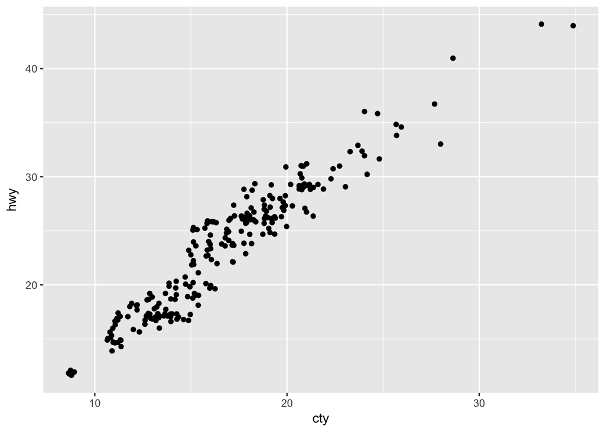

```r
ggplot(data = mpg, mapping = aes(x = cty, y = hwy)) + geom_jitter()
```

The graph shows datapoints close together and on top of each other. We cannot see the values of many points placed on top of each other. We can spread the points out by using geom_jitter().

## 2

The width and height parameters control the amount of jittering. The value is added to both sides, in positive and negative directions, of a datapoint so the total amount of jittering is doubled the values specified.

## 3

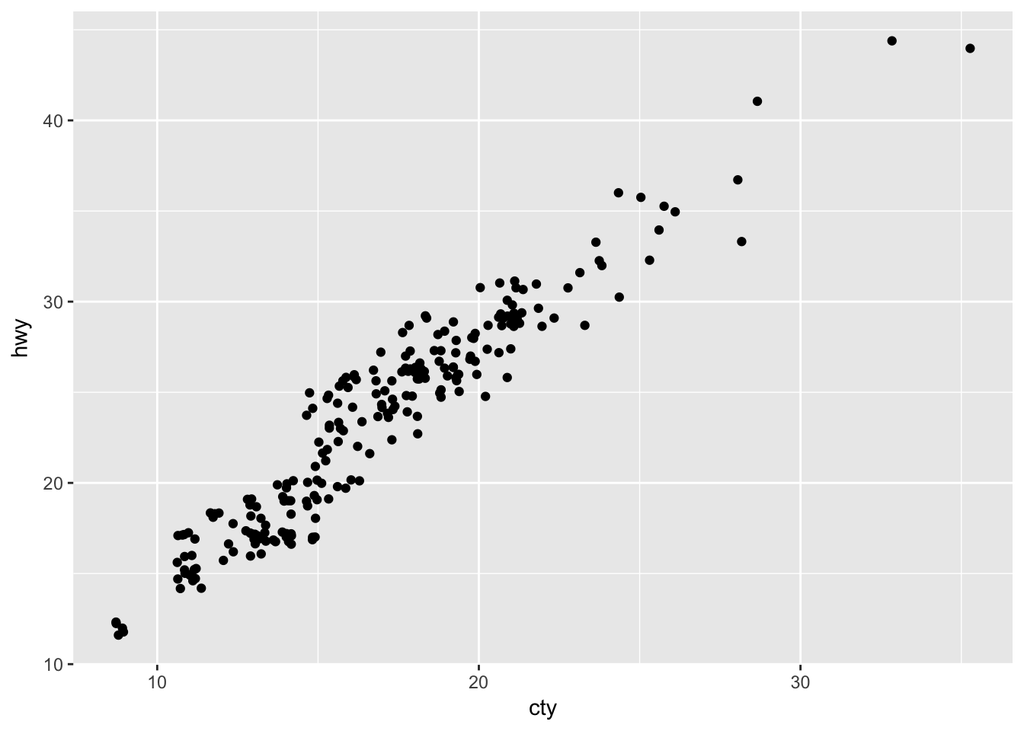

```r
ggplot(data = mpg, mapping = aes(x = cty, y = hwy)) + geom_jitter()
```

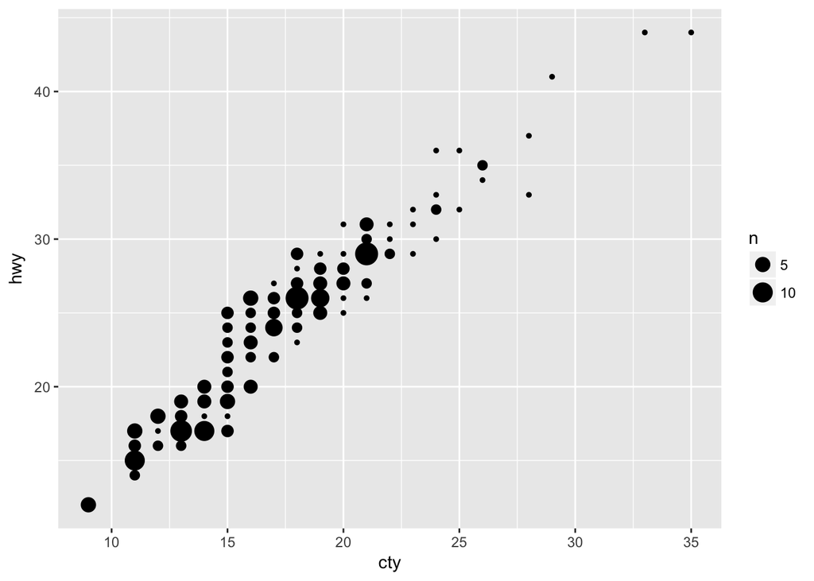

```r
ggplot(data = mpg, mapping = aes(x = cty, y = hwy)) + geom_count()
```

Geom_count counts the number of datapoints at each location and then associates the counts with point sizes/areas. A legend can be displayed to show the relationship between point size and data points. Geom_jitter is useful for small data and works to spread out the datapoints. Both geoms work to clarify overlapping datapoints.

## 4

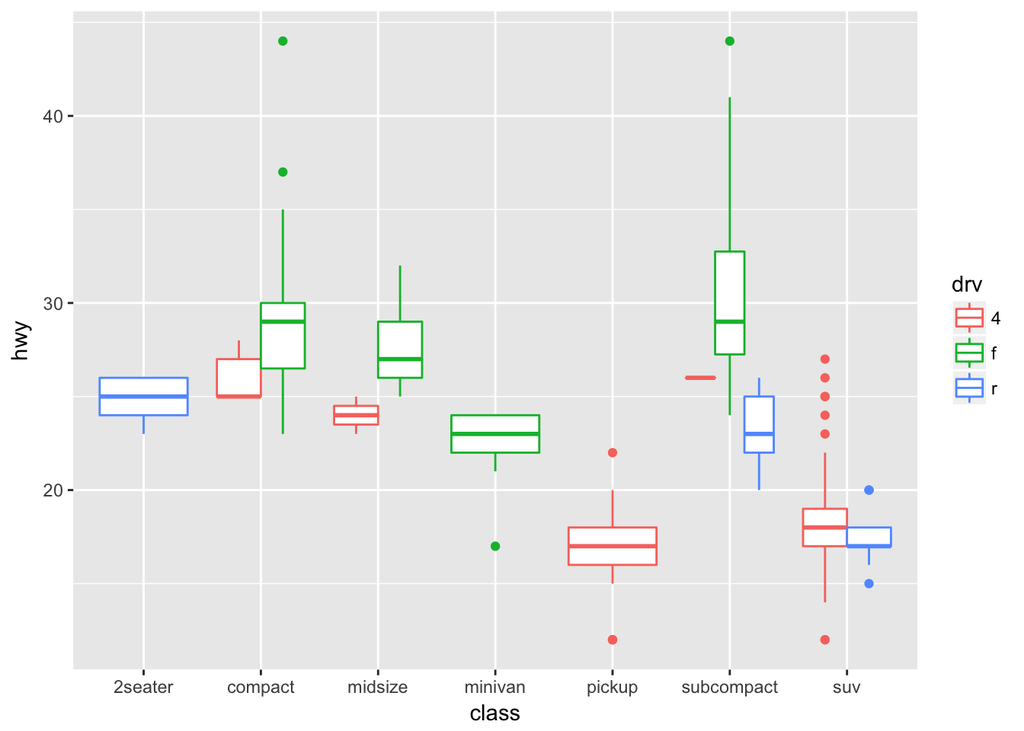

```r
ggplot(data = mpg, mapping = aes(x = class, y = hwy)) +
  geom_boxplot(mapping = aes(colour = drv), position = "dodge")
```

Boxplots’ default position is “dodge” and it is automatic when an aesthetic is a factor. It produces the same graph with or without position specification.

# 1.4

## 1

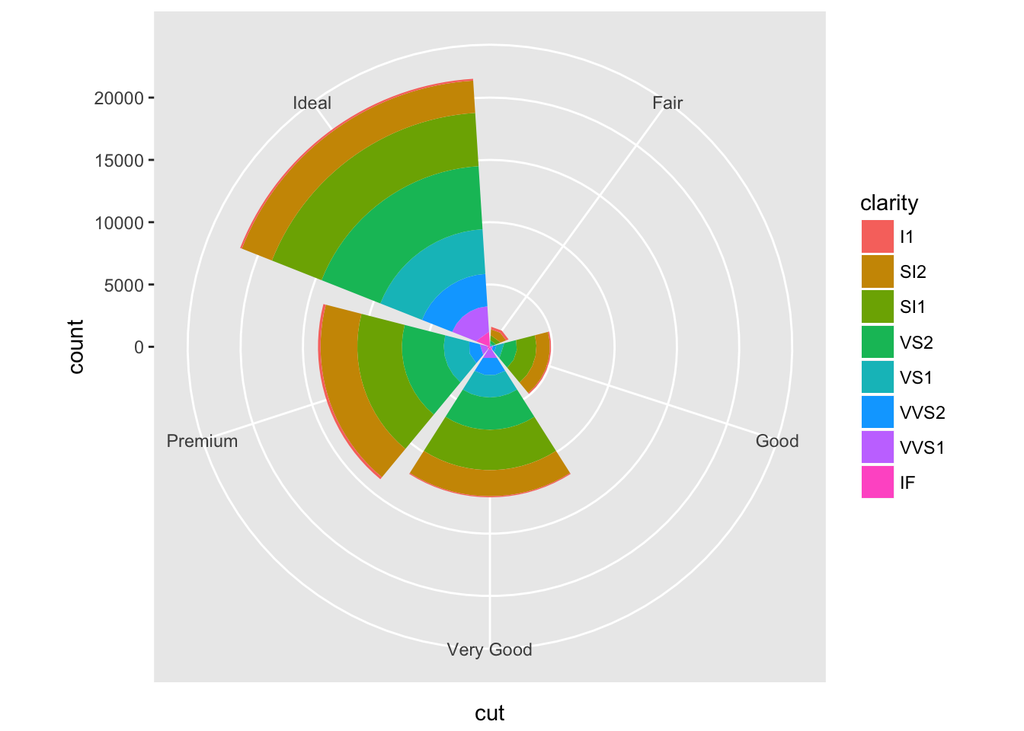

```r
ggplot(data = diamonds) +
  geom_bar(mapping = aes(x = cut, fill = clarity)) + coord_polar()
```

## 2

Labs() allow us to put labels on an aesthetic, titles to a graph, or captions.

## 3

Coord_map() shows a portion of the earth on a 2d plane using a project from the mapproj package. This does not preserve straight lines while coord_quickmap() preserves straight lines so it works best for small areas near the equator.

## 4

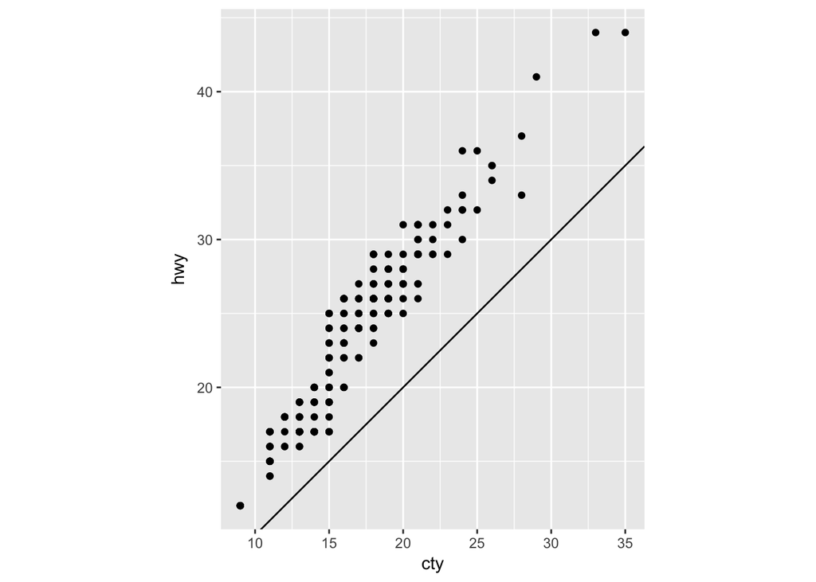

```r
ggplot(data = mpg, mapping = aes(x = cty, y = hwy)) +
  geom_point() + geom_abline() + coord_fixed()
```

Coord_fixed() shows the city mileage to highway mileage as points from our dataset. Geom_abline() gives a straight line specified by a slope and intercept. This geom provides a 1:1 comparison for our point plot. This comparison shows that in our dataset, cars get more highway mileage per city mileage.

# 4.4

## 1

```r
my_variable <- 10
#my_varıable
```

The code does not work because my_variable in the second line is not the same variable as the first. The second variable does not exist.

## 2

library(tidyverse)

ggplot(data = mpg) + geom_point(mapping = aes(x = displ, y = hwy))

filter(mpg, cyl == 8) filter(diamonds, carat > 3)

## 3

A list of keyboard shortcuts appear. From menu -> Tools -> Keyboard Shortcuts Help.

# 1.6

## 1

```r
library(nycflights13)
```

### 1

```r
arrdelay <- filter(flights, arr_delay >= 120)
```

10200 flights with 2 or more hours of arrival delay.

### 2

```r
houston <- c("IAH", "HOU")
houstindest <- filter(flights, dest %in% houston)
```

9313 flights to Houston at destinations “IAH” or “HOU”.

### 3

```r
carriers <- c("UA", "AA", "DL")
threecarriers <- filter(flights, carrier %in% carriers)
```

139504 flights operated by UA, AA, and DL.

### 4

```r
summermonths <- c("7", "8", "9")
summerflights <- filter(flights, month %in% summermonths)
```

86326 flights in July, August, and September.

### 5

```r
arrlate <- filter(flights, arr_delay > 120 & dep_delay <= "0")
```

29 flights arrived 2 hours late but didnt leave late.

### 6

```r
diff <- flights$sched_arr_time - flights$arr_time
delayed <- filter(flights, dep_delay >= "60" & diff > "30")
```

2348 flights delayed by at least an hour but made up more than 30 mins in flight.

### 7

```r
between <- filter(flights, dep_time >= "0000" & dep_time <= "600")
```

239607 flights departed between midnight and 6am inclusive.

## 2

```r
between1 <- filter(flights, between(month, 7, 9))
```

We can try this on the months question because it involved only one variable with multiple values. We get the same number of flights. Between creates lower and upper bounds for a value.

## 3

```r
summary(flights$dep_time) #or
```

```
##    Min. 1st Qu.  Median    Mean 3rd Qu.    Max.    NA's
##       1     907    1401    1349    1744    2400    8255
```

```r
summary(flights)
```

```
##       year          month             day           dep_time
##  Min.   :2013   Min.   : 1.000   Min.   : 1.00   Min.   :   1
##  1st Qu.:2013   1st Qu.: 4.000   1st Qu.: 8.00   1st Qu.: 907
##  Median :2013   Median : 7.000   Median :16.00   Median :1401
##  Mean   :2013   Mean   : 6.549   Mean   :15.71   Mean   :1349
##  3rd Qu.:2013   3rd Qu.:10.000   3rd Qu.:23.00   3rd Qu.:1744
##  Max.   :2013   Max.   :12.000   Max.   :31.00   Max.   :2400
##                                                  NA's   :8255
##  sched_dep_time   dep_delay          arr_time    sched_arr_time
##  Min.   : 106   Min.   : -43.00   Min.   :   1   Min.   :   1
##  1st Qu.: 906   1st Qu.:  -5.00   1st Qu.:1104   1st Qu.:1124
##  Median :1359   Median :  -2.00   Median :1535   Median :1556
##  Mean   :1344   Mean   :  12.64   Mean   :1502   Mean   :1536
##  3rd Qu.:1729   3rd Qu.:  11.00   3rd Qu.:1940   3rd Qu.:1945
##  Max.   :2359   Max.   :1301.00   Max.   :2400   Max.   :2359
##                 NA's   :8255      NA's   :8713
##    arr_delay          carrier              flight       tailnum
##  Min.   : -86.000   Length:336776      Min.   :   1   Length:336776
##  1st Qu.: -17.000   Class :character   1st Qu.: 553   Class :character
##  Median :  -5.000   Mode  :character   Median :1496   Mode  :character
##  Mean   :   6.895                      Mean   :1972
##  3rd Qu.:  14.000                      3rd Qu.:3465
##  Max.   :1272.000                      Max.   :8500
##  NA's   :9430
##     origin              dest              air_time        distance
##  Length:336776      Length:336776      Min.   : 20.0   Min.   :  17
##  Class :character   Class :character   1st Qu.: 82.0   1st Qu.: 502
##  Mode  :character   Mode  :character   Median :129.0   Median : 872
##                                        Mean   :150.7   Mean   :1040
##                                        3rd Qu.:192.0   3rd Qu.:1389
##                                        Max.   :695.0   Max.   :4983
##                                        NA's   :9430
##       hour           minute        time_hour
##  Min.   : 1.00   Min.   : 0.00   Min.   :2013-01-01 05:00:00
##  1st Qu.: 9.00   1st Qu.: 8.00   1st Qu.:2013-04-04 13:00:00
##  Median :13.00   Median :29.00   Median :2013-07-03 10:00:00
##  Mean   :13.18   Mean   :26.23   Mean   :2013-07-03 05:02:36
##  3rd Qu.:17.00   3rd Qu.:44.00   3rd Qu.:2013-10-01 07:00:00
##  Max.   :23.00   Max.   :59.00   Max.   :2013-12-31 23:00:00
##
```

8255 NAs from dep_time. Dep_delay, arr_time, arr_delay, and air_time have missing values. Some of these flights could be canceled flights.

## 4

```r
NA^0
```

```
## [1] 1
```

```r
NA|TRUE
```

```
## [1] TRUE
```

```r
FALSE & NA
```

```
## [1] FALSE
```

Anything raised to 0 is 1. The pipe | means “or” so NA or TRUE will return TRUE because we can have either or. We cant have FALSE and NA since there is a FALSE so that statement itself will return FALSE.

# 1.7

## 1

```r
arrange(flights, desc(is.na(arr_delay))) %>% select(arr_delay)
```

```
## # A tibble: 336,776 x 1
##    arr_delay
##        <dbl>
##  1        NA
##  2        NA
##  3        NA
##  4        NA
##  5        NA
##  6        NA
##  7        NA
##  8        NA
##  9        NA
## 10        NA
## # ... with 336,766 more rows
```

All the NAs are moved to the top. The display limit only shows NAs.

## 2

```r
arrange(flights, desc(arr_delay))
```

```
## # A tibble: 336,776 x 19
##     year month   day dep_time sched_dep_time dep_delay arr_time
##    <int> <int> <int>    <int>          <int>     <dbl>    <int>
##  1  2013     1     9      641            900      1301     1242
##  2  2013     6    15     1432           1935      1137     1607
##  3  2013     1    10     1121           1635      1126     1239
##  4  2013     9    20     1139           1845      1014     1457
##  5  2013     7    22      845           1600      1005     1044
##  6  2013     4    10     1100           1900       960     1342
##  7  2013     3    17     2321            810       911      135
##  8  2013     7    22     2257            759       898      121
##  9  2013    12     5      756           1700       896     1058
## 10  2013     5     3     1133           2055       878     1250
## # ... with 336,766 more rows, and 12 more variables: sched_arr_time <int>,
## #   arr_delay <dbl>, carrier <chr>, flight <int>, tailnum <chr>,
## #   origin <chr>, dest <chr>, air_time <dbl>, distance <dbl>, hour <dbl>,
## #   minute <dbl>, time_hour <dttm>
```

Sort in descending order so the most delayed flights by arrival are on top.

## 3

```r
arrange(flights, dep_delay)
```

```
## # A tibble: 336,776 x 19
##     year month   day dep_time sched_dep_time dep_delay arr_time
##    <int> <int> <int>    <int>          <int>     <dbl>    <int>
##  1  2013    12     7     2040           2123       -43       40
##  2  2013     2     3     2022           2055       -33     2240
##  3  2013    11    10     1408           1440       -32     1549
##  4  2013     1    11     1900           1930       -30     2233
##  5  2013     1    29     1703           1730       -27     1947
##  6  2013     8     9      729            755       -26     1002
##  7  2013    10    23     1907           1932       -25     2143
##  8  2013     3    30     2030           2055       -25     2213
##  9  2013     3     2     1431           1455       -24     1601
## 10  2013     5     5      934            958       -24     1225
## # ... with 336,766 more rows, and 12 more variables: sched_arr_time <int>,
## #   arr_delay <dbl>, carrier <chr>, flight <int>, tailnum <chr>,
## #   origin <chr>, dest <chr>, air_time <dbl>, distance <dbl>, hour <dbl>,
## #   minute <dbl>, time_hour <dttm>
```

Dep_delay as negative values left earliest relative to scheduled departures. Not in descending order because the variable values start with the most negative numbers and those are the ones that departed the earliest relative to scheduled departures.

## 4

```r
new <- mutate(flights, timeinair = ifelse((arr_time - dep_time < 0),
    2400+(arr_time - dep_time), arr_time - dep_time))

arrange(new, timeinair)
```

```
## # A tibble: 336,776 x 20
##     year month   day dep_time sched_dep_time dep_delay arr_time
##    <int> <int> <int>    <int>          <int>     <dbl>    <int>
##  1  2013     1     5     1323           1325        -2     1358
##  2  2013     2    22     1312           1316        -4     1347
##  3  2013     9     3     1203           1153        10     1238
##  4  2013     8    14      722            730        -8      758
##  5  2013     8    18      722            729        -7      758
##  6  2013     9    24      718            725        -7      754
##  7  2013     3    27     1418           1329        49     1455
##  8  2013     5     8       16           2159       137       53
##  9  2013     9     4      717            725        -8      754
## 10  2013     2    24     1315           1320        -5     1353
## # ... with 336,766 more rows, and 13 more variables: sched_arr_time <int>,
## #   arr_delay <dbl>, carrier <chr>, flight <int>, tailnum <chr>,
## #   origin <chr>, dest <chr>, air_time <dbl>, distance <dbl>, hour <dbl>,
## #   minute <dbl>, time_hour <dttm>, timeinair <dbl>
```

If flights took off at 11:59 or 23:59, we would take the difference to find time in the air, but it would be negative because arrival time is smaller than departure time. We would then add another day to it, represented by 2400. The other case is that the time differences are not negative. We would then sort with ascending order to see the flights with shortest time in the air.

# 1.8

## 1

```r
select(flights, dep_time, dep_delay, arr_time, arr_delay)
```

```
## # A tibble: 336,776 x 4
##    dep_time dep_delay arr_time arr_delay
##       <int>     <dbl>    <int>     <dbl>
##  1      517         2      830        11
##  2      533         4      850        20
##  3      542         2      923        33
##  4      544        -1     1004       -18
##  5      554        -6      812       -25
##  6      554        -4      740        12
##  7      555        -5      913        19
##  8      557        -3      709       -14
##  9      557        -3      838        -8
## 10      558        -2      753         8
## # ... with 336,766 more rows
```

```r
#select(flights, "dep_time", "dep_delay", "arr_time", "arr_delay")
#select(flights, c(dep_time, dep_delay, arr_time, arr_delay))
```

3 ways to select the 4 columns and display the same thing.

## 2

```r
select(flights, dep_time, dep_time, dep_time)
```

```
## # A tibble: 336,776 x 1
##    dep_time
##       <int>
##  1      517
##  2      533
##  3      542
##  4      544
##  5      554
##  6      554
##  7      555
##  8      557
##  9      557
## 10      558
## # ... with 336,766 more rows
```

We would get the variable’s column once regardless of how many times the name is repeated.

## 3

```r
vars <- c("year", "month", "day", "dep_delay", "arr_delay")
select(flights, one_of(vars))
```

```
## # A tibble: 336,776 x 5
##     year month   day dep_delay arr_delay
##    <int> <int> <int>     <dbl>     <dbl>
##  1  2013     1     1         2        11
##  2  2013     1     1         4        20
##  3  2013     1     1         2        33
##  4  2013     1     1        -1       -18
##  5  2013     1     1        -6       -25
##  6  2013     1     1        -4        12
##  7  2013     1     1        -5        19
##  8  2013     1     1        -3       -14
##  9  2013     1     1        -3        -8
## 10  2013     1     1        -2         8
## # ... with 336,766 more rows
```

We can select variables based off names. One_of selects the variables in the vector and gives values associated with that variable. It is helpful because if you want to select many variables, it would be easier to just use one_of so we select all the variables at once.

## 4

```r
select(flights, contains("TIME"))
```

```
## # A tibble: 336,776 x 6
##    dep_time sched_dep_time arr_time sched_arr_time air_time
##       <int>          <int>    <int>          <int>    <dbl>
##  1      517            515      830            819      227
##  2      533            529      850            830      227
##  3      542            540      923            850      160
##  4      544            545     1004           1022      183
##  5      554            600      812            837      116
##  6      554            558      740            728      150
##  7      555            600      913            854      158
##  8      557            600      709            723       53
##  9      557            600      838            846      140
## 10      558            600      753            745      138
## # ... with 336,766 more rows, and 1 more variables: time_hour <dttm>
```

```r
#to change default
select(flights, contains("TIME", ignore.case = FALSE))
```

```
## # A tibble: 336,776 x 0
```

```r
variable.names(flights)
```

```
##  [1] "year"           "month"          "day"            "dep_time"
##  [5] "sched_dep_time" "dep_delay"      "arr_time"       "sched_arr_time"
##  [9] "arr_delay"      "carrier"        "flight"         "tailnum"
## [13] "origin"         "dest"           "air_time"       "distance"
## [17] "hour"           "minute"         "time_hour"
```

# 1.9

## 1

```r
mutate(flights, dep_time_new = (dep_time %/% 100) * 60 +
         (dep_time %% 100))
```

```
## # A tibble: 336,776 x 20
##     year month   day dep_time sched_dep_time dep_delay arr_time
##    <int> <int> <int>    <int>          <int>     <dbl>    <int>
##  1  2013     1     1      517            515         2      830
##  2  2013     1     1      533            529         4      850
##  3  2013     1     1      542            540         2      923
##  4  2013     1     1      544            545        -1     1004
##  5  2013     1     1      554            600        -6      812
##  6  2013     1     1      554            558        -4      740
##  7  2013     1     1      555            600        -5      913
##  8  2013     1     1      557            600        -3      709
##  9  2013     1     1      557            600        -3      838
## 10  2013     1     1      558            600        -2      753
## # ... with 336,766 more rows, and 13 more variables: sched_arr_time <int>,
## #   arr_delay <dbl>, carrier <chr>, flight <int>, tailnum <chr>,
## #   origin <chr>, dest <chr>, air_time <dbl>, distance <dbl>, hour <dbl>,
## #   minute <dbl>, time_hour <dttm>, dep_time_new <dbl>
```

```r
mutate(flights, sched_dep_time_new = (sched_dep_time %/% 100) * 60 +
         (sched_dep_time %% 100))
```

```
## # A tibble: 336,776 x 20
##     year month   day dep_time sched_dep_time dep_delay arr_time
##    <int> <int> <int>    <int>          <int>     <dbl>    <int>
##  1  2013     1     1      517            515         2      830
##  2  2013     1     1      533            529         4      850
##  3  2013     1     1      542            540         2      923
##  4  2013     1     1      544            545        -1     1004
##  5  2013     1     1      554            600        -6      812
##  6  2013     1     1      554            558        -4      740
##  7  2013     1     1      555            600        -5      913
##  8  2013     1     1      557            600        -3      709
##  9  2013     1     1      557            600        -3      838
## 10  2013     1     1      558            600        -2      753
## # ... with 336,766 more rows, and 13 more variables: sched_arr_time <int>,
## #   arr_delay <dbl>, carrier <chr>, flight <int>, tailnum <chr>,
## #   origin <chr>, dest <chr>, air_time <dbl>, distance <dbl>, hour <dbl>,
## #   minute <dbl>, time_hour <dttm>, sched_dep_time_new <dbl>
```

We apply the conversion to both variables. We use integer division to get the number of hours and then multiply that by 60, which gives the number of minutes from observed hours. We then add the minutes that was originally part of the original hour:minute format using modulus division. This conversion gives total minutes since midnight.

## 2

Arr_time is in hour:min format. Air_time is in number of minutes. Dep_time is in hour:min. Expect them to be in the same format. Need to convert one of them (either arr_time or dep_time) so they’re in the same format in order to find air_time. Calcair_time is the new calculated air_time that should be the same as air_time.

## 3

```r
#flights$air_time
flights <- mutate(flights, dep_time_new = (dep_time %/% 100) * 60 +
         (dep_time %% 100), arr_time_new = (arr_time %/% 100) * 60 +
         (arr_time %% 100))

flights <- mutate(flights, calcair_time = dep_time_new - arr_time_new)

head(ifelse(flights$calcair_time == flights$air_time, "yes", "no"), 10)
```

```
##  [1] "no" "no" "no" "no" "no" "no" "no" "no" "no" "no"
```

I only printed 10 rows but calcair_time generally does not equal the original air time in the dataset.

## 4

```r
head(ifelse(flights$calcair_time == flights$air_time +- 15 , "yes", "no"), 10)
```

```
##  [1] "no" "no" "no" "no" "no" "no" "no" "no" "no" "no"
```

An error tolerance can be 15 minutes because the DOT counts departing 15 minutes later than original scheduled time to be “delayed.” I only printed the first 10 rows but a large fraction of calculated air_time is still different from the original air_time.

## 5

```r
mutate(flights, sched_dep_time = (sched_dep_time %/% 100) * 60 +
         (sched_dep_time %% 100), dep_time = (dep_time %/% 100) * 60 +
         (dep_time %% 100))
```

```
## # A tibble: 336,776 x 22
##     year month   day dep_time sched_dep_time dep_delay arr_time
##    <int> <int> <int>    <dbl>          <dbl>     <dbl>    <int>
##  1  2013     1     1      317            315         2      830
##  2  2013     1     1      333            329         4      850
##  3  2013     1     1      342            340         2      923
##  4  2013     1     1      344            345        -1     1004
##  5  2013     1     1      354            360        -6      812
##  6  2013     1     1      354            358        -4      740
##  7  2013     1     1      355            360        -5      913
##  8  2013     1     1      357            360        -3      709
##  9  2013     1     1      357            360        -3      838
## 10  2013     1     1      358            360        -2      753
## # ... with 336,766 more rows, and 15 more variables: sched_arr_time <int>,
## #   arr_delay <dbl>, carrier <chr>, flight <int>, tailnum <chr>,
## #   origin <chr>, dest <chr>, air_time <dbl>, distance <dbl>, hour <dbl>,
## #   minute <dbl>, time_hour <dttm>, dep_time_new <dbl>,
## #   arr_time_new <dbl>, calcair_time <dbl>
```

```r
#ifelse(flights$dep_time - flights$sched_dep_time == flights$dep_delay, "yes", "no")
```

Dep_delay should be equal to dep_time - sched_dep_time after reformatting. There are a lot more observations where dep_delay does equal calculated departure delay.

## 6

```r
filter(flights, min_rank(desc(dep_delay)) <= 10)
```

```
## # A tibble: 10 x 22
##     year month   day dep_time sched_dep_time dep_delay arr_time
##    <int> <int> <int>    <int>          <int>     <dbl>    <int>
##  1  2013     1     9      641            900      1301     1242
##  2  2013     1    10     1121           1635      1126     1239
##  3  2013    12     5      756           1700       896     1058
##  4  2013     3    17     2321            810       911      135
##  5  2013     4    10     1100           1900       960     1342
##  6  2013     6    15     1432           1935      1137     1607
##  7  2013     6    27      959           1900       899     1236
##  8  2013     7    22      845           1600      1005     1044
##  9  2013     7    22     2257            759       898      121
## 10  2013     9    20     1139           1845      1014     1457
## # ... with 15 more variables: sched_arr_time <int>, arr_delay <dbl>,
## #   carrier <chr>, flight <int>, tailnum <chr>, origin <chr>, dest <chr>,
## #   air_time <dbl>, distance <dbl>, hour <dbl>, minute <dbl>,
## #   time_hour <dttm>, dep_time_new <dbl>, arr_time_new <dbl>,
## #   calcair_time <dbl>
```

I used min_rank and then used descending so the 10 longest delays are on top. I would use the pipe operator, %>%, to then rank additional columns to break the tie in dep_delay.

## 7

```r
1:3 + 1:10
```

```
##  [1]  2  4  6  5  7  9  8 10 12 11
```

It generates a vector that is a result of adding two vectors (1:3) and (1:10) and repeating on the shorter vector and adding the 3 values to the longer vector.

# Public Sector Application: Flight Data

## 2.1

```r
chi.flights_Jan <- read_csv("Jan.csv")
chi.flights_Feb <- read_csv("Feb.csv")
chi.flights_March <- read_csv("March.csv")
chi.flights_April <- read_csv("April.csv")
chi.flights_May <- read_csv("May.csv")
chi.flights_June <- read_csv("June.csv")
chi.flights_July <- read_csv("July.csv")
chi.flights_Aug <- read_csv("Aug.csv")
chi.flights_Sept <- read_csv("Sept.csv")
chi.flights_Oct <- read_csv("Oct.csv")
chi.flights_Nov <- read_csv("Nov.csv")
chi.flights_Dec <- read_csv("Dec.csv")
totflights <- bind_rows(chi.flights_Jan, chi.flights_Feb, chi.flights_March, chi.flights_April, chi.flights_May, chi.flights_June, chi.flights_July, chi.flights_Aug, chi.flights_Sept, chi.flights_Oct, chi.flights_Nov, chi.flights_Dec)
```

I saved my dataframe as totflights (total flights), not chiflights.

# 2.2

## 1

There is no unique identifier for each flight in the dataset.

## 2

```r
print(totflights) #shows the first 10 rows
```

```
## # A tibble: 675,822 x 57
##     YEAR QUARTER MONTH DAY_OF_MONTH DAY_OF_WEEK    FL_DATE UNIQUE_CARRIER
##    <int>   <int> <int>        <int>       <int>     <date>          <chr>
##  1  2016       1     1            1           5 2016-01-01             AA
##  2  2016       1     1            3           7 2016-01-03             AA
##  3  2016       1     1            4           1 2016-01-04             AA
##  4  2016       1     1            1           5 2016-01-01             AA
##  5  2016       1     1            2           6 2016-01-02             AA
##  6  2016       1     1            3           7 2016-01-03             AA
##  7  2016       1     1            4           1 2016-01-04             AA
##  8  2016       1     1            5           2 2016-01-05             AA
##  9  2016       1     1            6           3 2016-01-06             AA
## 10  2016       1     1            7           4 2016-01-07             AA
## # ... with 675,812 more rows, and 50 more variables: AIRLINE_ID <int>,
## #   CARRIER <chr>, TAIL_NUM <chr>, FL_NUM <int>, ORIGIN_AIRPORT_ID <int>,
## #   ORIGIN_AIRPORT_SEQ_ID <int>, ORIGIN_CITY_MARKET_ID <int>,
## #   ORIGIN <chr>, ORIGIN_CITY_NAME <chr>, ORIGIN_STATE_ABR <chr>,
## #   ORIGIN_STATE_FIPS <chr>, ORIGIN_STATE_NM <chr>, DEST_AIRPORT_ID <int>,
## #   DEST_AIRPORT_SEQ_ID <int>, DEST_CITY_MARKET_ID <int>, DEST <chr>,
## #   DEST_CITY_NAME <chr>, DEST_STATE_ABR <chr>, DEST_STATE_FIPS <chr>,
## #   DEST_STATE_NM <chr>, DEST_WAC <int>, CRS_DEP_TIME <chr>,
## #   DEP_TIME <chr>, DEP_DELAY <dbl>, DEP_DELAY_NEW <dbl>, DEP_DEL15 <dbl>,
## #   DEP_DELAY_GROUP <int>, DEP_TIME_BLK <chr>, CRS_ARR_TIME <chr>,
## #   ARR_TIME <chr>, ARR_DELAY <dbl>, ARR_DELAY_NEW <dbl>, ARR_DEL15 <dbl>,
## #   ARR_DELAY_GROUP <int>, ARR_TIME_BLK <chr>, CANCELLED <dbl>,
## #   CANCELLATION_CODE <chr>, DIVERTED <dbl>, CRS_ELAPSED_TIME <dbl>,
## #   ACTUAL_ELAPSED_TIME <dbl>, AIR_TIME <dbl>, FLIGHTS <dbl>,
## #   DISTANCE <dbl>, DISTANCE_GROUP <int>, CARRIER_DELAY <dbl>,
## #   WEATHER_DELAY <dbl>, NAS_DELAY <dbl>, SECURITY_DELAY <dbl>,
## #   LATE_AIRCRAFT_DELAY <dbl>, X57 <chr>
```

```r
head(totflights) #shows the first 6 rows
```

```
## # A tibble: 6 x 57
##    YEAR QUARTER MONTH DAY_OF_MONTH DAY_OF_WEEK    FL_DATE UNIQUE_CARRIER
##   <int>   <int> <int>        <int>       <int>     <date>          <chr>
## 1  2016       1     1            1           5 2016-01-01             AA
## 2  2016       1     1            3           7 2016-01-03             AA
## 3  2016       1     1            4           1 2016-01-04             AA
## 4  2016       1     1            1           5 2016-01-01             AA
## 5  2016       1     1            2           6 2016-01-02             AA
## 6  2016       1     1            3           7 2016-01-03             AA
## # ... with 50 more variables: AIRLINE_ID <int>, CARRIER <chr>,
## #   TAIL_NUM <chr>, FL_NUM <int>, ORIGIN_AIRPORT_ID <int>,
## #   ORIGIN_AIRPORT_SEQ_ID <int>, ORIGIN_CITY_MARKET_ID <int>,
## #   ORIGIN <chr>, ORIGIN_CITY_NAME <chr>, ORIGIN_STATE_ABR <chr>,
## #   ORIGIN_STATE_FIPS <chr>, ORIGIN_STATE_NM <chr>, DEST_AIRPORT_ID <int>,
## #   DEST_AIRPORT_SEQ_ID <int>, DEST_CITY_MARKET_ID <int>, DEST <chr>,
## #   DEST_CITY_NAME <chr>, DEST_STATE_ABR <chr>, DEST_STATE_FIPS <chr>,
## #   DEST_STATE_NM <chr>, DEST_WAC <int>, CRS_DEP_TIME <chr>,
## #   DEP_TIME <chr>, DEP_DELAY <dbl>, DEP_DELAY_NEW <dbl>, DEP_DEL15 <dbl>,
## #   DEP_DELAY_GROUP <int>, DEP_TIME_BLK <chr>, CRS_ARR_TIME <chr>,
## #   ARR_TIME <chr>, ARR_DELAY <dbl>, ARR_DELAY_NEW <dbl>, ARR_DEL15 <dbl>,
## #   ARR_DELAY_GROUP <int>, ARR_TIME_BLK <chr>, CANCELLED <dbl>,
## #   CANCELLATION_CODE <chr>, DIVERTED <dbl>, CRS_ELAPSED_TIME <dbl>,
## #   ACTUAL_ELAPSED_TIME <dbl>, AIR_TIME <dbl>, FLIGHTS <dbl>,
## #   DISTANCE <dbl>, DISTANCE_GROUP <int>, CARRIER_DELAY <dbl>,
## #   WEATHER_DELAY <dbl>, NAS_DELAY <dbl>, SECURITY_DELAY <dbl>,
## #   LATE_AIRCRAFT_DELAY <dbl>, X57 <chr>
```

```r
str(totflights) #compactly displays internal structure of dataframe
```

```
## Classes 'tbl_df', 'tbl' and 'data.frame':    675822 obs. of  57 variables:
##  $ YEAR                 : int  2016 2016 2016 2016 2016 2016 2016 2016 2016 2016 ...
##  $ QUARTER              : int  1 1 1 1 1 1 1 1 1 1 ...
##  $ MONTH                : int  1 1 1 1 1 1 1 1 1 1 ...
##  $ DAY_OF_MONTH         : int  1 3 4 1 2 3 4 5 6 7 ...
##  $ DAY_OF_WEEK          : int  5 7 1 5 6 7 1 2 3 4 ...
##  $ FL_DATE              : Date, format: "2016-01-01" "2016-01-03" ...
##  $ UNIQUE_CARRIER       : chr  "AA" "AA" "AA" "AA" ...
##  $ AIRLINE_ID           : int  19805 19805 19805 19805 19805 19805 19805 19805 19805 19805 ...
##  $ CARRIER              : chr  "AA" "AA" "AA" "AA" ...
##  $ TAIL_NUM             : chr  "N3JUAA" "N3FKAA" "N3LMAA" "N3MAAA" ...
##  $ FL_NUM               : int  46 46 46 47 47 47 47 47 47 47 ...
##  $ ORIGIN_AIRPORT_ID    : int  14831 14831 14831 13930 13930 13930 13930 13930 13930 13930 ...
##  $ ORIGIN_AIRPORT_SEQ_ID: int  1483103 1483103 1483103 1393004 1393004 1393004 1393004 1393004 1393004 1393004 ...
##  $ ORIGIN_CITY_MARKET_ID: int  32457 32457 32457 30977 30977 30977 30977 30977 30977 30977 ...
```

[output cut: 43 more lines]

```r
glimpse(totflights) #redundant with str()
```

```
## Observations: 675,822
## Variables: 57
## $ YEAR                  <int> 2016, 2016, 2016, 2016, 2016, 2016, 2016...
## $ QUARTER               <int> 1, 1, 1, 1, 1, 1, 1, 1, 1, 1, 1, 1, 1, 1...
## $ MONTH                 <int> 1, 1, 1, 1, 1, 1, 1, 1, 1, 1, 1, 1, 1, 1...
## $ DAY_OF_MONTH          <int> 1, 3, 4, 1, 2, 3, 4, 5, 6, 7, 8, 9, 10, ...
## $ DAY_OF_WEEK           <int> 5, 7, 1, 5, 6, 7, 1, 2, 3, 4, 5, 6, 7, 1...
## $ FL_DATE               <date> 2016-01-01, 2016-01-03, 2016-01-04, 201...
## $ UNIQUE_CARRIER        <chr> "AA", "AA", "AA", "AA", "AA", "AA", "AA"...
## $ AIRLINE_ID            <int> 19805, 19805, 19805, 19805, 19805, 19805...
## $ CARRIER               <chr> "AA", "AA", "AA", "AA", "AA", "AA", "AA"...
## $ TAIL_NUM              <chr> "N3JUAA", "N3FKAA", "N3LMAA", "N3MAAA", ...
## $ FL_NUM                <int> 46, 46, 46, 47, 47, 47, 47, 47, 47, 47, ...
## $ ORIGIN_AIRPORT_ID     <int> 14831, 14831, 14831, 13930, 13930, 13930...
## $ ORIGIN_AIRPORT_SEQ_ID <int> 1483103, 1483103, 1483103, 1393004, 1393...
```

[output cut: 44 more lines]

```r
#View(totflights) #opens new viewer to see entire dataframe
summary(totflights) #gives summary statistics of all variables
```

```
##       YEAR         QUARTER          MONTH         DAY_OF_MONTH
##  Min.   :2016   Min.   :1.000   Min.   : 1.000   Min.   : 1.00
##  1st Qu.:2016   1st Qu.:2.000   1st Qu.: 4.000   1st Qu.: 8.00
##  Median :2016   Median :3.000   Median : 7.000   Median :16.00
##  Mean   :2016   Mean   :2.526   Mean   : 6.575   Mean   :15.76
##  3rd Qu.:2016   3rd Qu.:3.000   3rd Qu.: 9.000   3rd Qu.:23.00
##  Max.   :2016   Max.   :4.000   Max.   :12.000   Max.   :31.00
##
##   DAY_OF_WEEK       FL_DATE           UNIQUE_CARRIER       AIRLINE_ID
##  Min.   :1.000   Min.   :2016-01-01   Length:675822      Min.   :19393
##  1st Qu.:2.000   1st Qu.:2016-04-08   Class :character   1st Qu.:19790
##  Median :4.000   Median :2016-07-05   Mode  :character   Median :19977
##  Mean   :3.923   Mean   :2016-07-03                      Mean   :19919
##  3rd Qu.:6.000   3rd Qu.:2016-09-29                      3rd Qu.:20304
##  Max.   :7.000   Max.   :2016-12-31                      Max.   :21171
##
##    CARRIER            TAIL_NUM             FL_NUM     ORIGIN_AIRPORT_ID
##  Length:675822      Length:675822      Min.   :   1   Min.   :10135
##  Class :character   Class :character   1st Qu.: 734   1st Qu.:12889
##  Mode  :character   Mode  :character   Median :1717   Median :13930
##                                        Mean   :2286   Mean   :13194
##                                        3rd Qu.:3828   3rd Qu.:13930
##                                        Max.   :6899   Max.   :15919
##
##  ORIGIN_AIRPORT_SEQ_ID ORIGIN_CITY_MARKET_ID    ORIGIN
##  Min.   :1013503       Min.   :30135         Length:675822
##  1st Qu.:1288903       1st Qu.:30977         Class :character
##  Median :1393004       Median :30977         Mode  :character
##  Mean   :1319434       Mean   :31427
##  3rd Qu.:1393004       3rd Qu.:31650
##  Max.   :1591902       Max.   :35497
##
##  ORIGIN_CITY_NAME   ORIGIN_STATE_ABR   ORIGIN_STATE_FIPS
##  Length:675822      Length:675822      Length:675822
##  Class :character   Class :character   Class :character
##  Mode  :character   Mode  :character   Mode  :character
##
##
##
##
```

[output cut: 73 more lines]

```
##  Min.   :   0.0   Min.   :   0.0   Min.   :  0      Min.   :   0.0
##  1st Qu.:   0.0   1st Qu.:   0.0   1st Qu.:  0      1st Qu.:   0.0
##  Median :   0.0   Median :   3.5   Median :  0      Median :   0.0
##  Mean   :   3.5   Mean   :  17.5   Mean   :  0      Mean   :  24.6
##  3rd Qu.:   0.0   3rd Qu.:  21.0   3rd Qu.:  0      3rd Qu.:  30.0
##  Max.   :1157.0   Max.   :1233.0   Max.   :242      Max.   :1420.0
##  NA's   :548614   NA's   :548614   NA's   :548614   NA's   :548614
##      X57
##  Length:675822
##  Class :character
##  Mode  :character
##
##
##
##
```

### 2.1

Nonredundant methods are str(totflights), View(totflights), and summary(totflights).

### 2.2

From str(totflights), we can see all the types of each variable. From View(totflights), we can see the entire dataframe. Summary(totflights) gives quarter statistics of each variable by values in the variable.

### 2.3

utils::str(object, …) utils::View(object, title) base::summary(object, …)

Above are the nonredundant methods in their generic or default form.

# 2.3

## 1

```r
library(testthat)
test_that("test", expect_equal(nrow(totflights),675822))
```

It doesn’t print “test failed” so it passed.

## 2

```r
#View(select(totflights, ORIGIN_STATE_NM, DEST_STATE_NM))

"Illinois" %in% totflights$ORIGIN_STATE_NM | "Illinois" %in%
          totflights$DEST_STATE_NM
```

```
## [1] TRUE
```

```r
ifelse (("Illinois" %in% totflights$ORIGIN_STATE_NM | "Illinois" %in%
          totflights$DEST_STATE_NM), print("Yes"), print("No"))
```

```
## [1] "Yes"
```

```
## [1] "Yes"
```

The second test will print “Yes” if Illinois is in either column, which is what we want. I tested using other words to substitute for “Illinois” changing only one column at a time, which still prints “Yes”, and tested substituting the words for both columns and it prints “No” when both columns are not “Illinois”. So Illinois is in either columns for all rows.

## 3

```r
totflights <- filter(totflights, totflights$DEST != "ORD" &
                  totflights$DEST != "MDW")
```

Dropping flights with DEST to ORD or MDW, 344131 flights are left.

## 4

```r
newflights <- filter(totflights, totflights$ORIGIN != "ORD" &
                       totflights$ORIGIN != "MDW") # does not have ORD or MDW in ORIGIN or DEST.

group_by(newflights, ORIGIN) %>% summarise(count=n()) %>%
  arrange(desc(count))
```

```
## # A tibble: 10 x 2
##    ORIGIN count
##     <chr> <int>
##  1    ATL  2966
##  2    PIA  2001
##  3    MLI  1984
##  4    BMI  1517
##  5    DTW  1233
##  6    MSP  1021
##  7    DFW   655
##  8    SPI   648
##  9    DEN   126
## 10    IAH    89
```

```r
# 5 most common origins
group_by(newflights, DEST) %>% summarise(count=n()) %>%
  arrange(desc(count)) # 5 most common destinations.
```

```
## # A tibble: 10 x 2
##     DEST count
##    <chr> <int>
##  1   ATL  2968
##  2   PIA  1999
##  3   MLI  1926
##  4   BMI  1517
##  5   DTW  1228
##  6   MSP  1022
##  7   DFW   656
##  8   SPI   648
##  9   DEN   186
## 10   IAH    90
```

```r
group_by(newflights, ORIGIN, DEST, ORIGIN_CITY_NAME, DEST_CITY_NAME) %>%
  count(ORIGIN) %>% arrange(desc(n)) #cities
```

```
## # A tibble: 26 x 5
## # Groups:   ORIGIN, DEST, ORIGIN_CITY_NAME, DEST_CITY_NAME [26]
##    ORIGIN  DEST       ORIGIN_CITY_NAME         DEST_CITY_NAME     n
##     <chr> <chr>                  <chr>                  <chr> <int>
##  1    ATL   PIA            Atlanta, GA             Peoria, IL  1022
##  2    PIA   ATL             Peoria, IL            Atlanta, GA  1022
##  3    BMI   ATL Bloomington/Normal, IL            Atlanta, GA  1003
##  4    ATL   BMI            Atlanta, GA Bloomington/Normal, IL  1002
##  5    MLI   ATL             Moline, IL            Atlanta, GA   943
##  6    ATL   MLI            Atlanta, GA             Moline, IL   942
##  7    DFW   SPI  Dallas/Fort Worth, TX        Springfield, IL   648
##  8    SPI   DFW        Springfield, IL  Dallas/Fort Worth, TX   648
##  9    DTW   PIA            Detroit, MI             Peoria, IL   576
## 10    PIA   DTW             Peoria, IL            Detroit, MI   575
## # ... with 16 more rows
```

## 5

```r
chi.flights_Jan <- read_csv("Jan.csv")
chi.flights_Feb <- read_csv("Feb.csv")
chi.flights_March <- read_csv("March.csv")
chi.flights_April <- read_csv("April.csv")
chi.flights_May <- read_csv("May.csv")
chi.flights_June <- read_csv("June.csv")
chi.flights_July <- read_csv("July.csv")
chi.flights_Aug <- read_csv("Aug.csv")
chi.flights_Sept <- read_csv("Sept.csv")
chi.flights_Oct <- read_csv("Oct.csv")
chi.flights_Nov <- read_csv("Nov.csv")
chi.flights_Dec <- read_csv("Dec.csv")
totflights1 <- bind_rows(chi.flights_Jan, chi.flights_Feb, chi.flights_March, chi.flights_April, chi.flights_May, chi.flights_June, chi.flights_July, chi.flights_Aug, chi.flights_Sept, chi.flights_Oct, chi.flights_Nov, chi.flights_Dec)

newflights1 <- filter(totflights1, totflights1$DEST == "MDW" | totflights1$DEST == "ORD" | totflights1$ORIGIN == "MDW" | totflights1$ORIGIN == "ORD") #flights to or from Midway or Ohare only
```

Since we’re limiting flights as to or from Midway or Ohare, it should have almost, if not all, the flights in the original total flights dataframe. It should be close to 675,822, which it is, at 663,582 flights. The difference of 12,240 seen earlier might be due to a small number of flights into Illinois using private or much smaller Illinois airports that are not Ohare or Midway.

http://www.chicagotribune.com/news/ct-ohare-midway-flights-down-0127-20170126-story.html Flights numbers at OHare: 867,635 Flight numbers at Midway: 253,046 Ohare and Midway Total: 1,120,681 (Chicago Tribune)

http://www.flychicago.com/SiteCollectionDocuments/Business/FactAndFigures/AirTraffic/1216%20ORD%20SUMMARY.pdf Ohare Total: 867,635

http://www.flychicago.com/SiteCollectionDocuments/Business/FactAndFigures/AirTraffic/1216%20MDW%20SUMMARY.pdf Midway Total: 253,046

Ohare and Midway Total: 867,635 + 253,046 = 1,120,681 (Fly Chicago, Chicago Department of Aviation)

The numbers from the two sources agree with each other but the BTS dataset does not match the sources. A possible reason is that the sources from Chicago Tribune and Fly Chicago are both from the Department of Aviation and report total aircraft operations, comprised of air carrier, general aviation, and others from both domestic and international operations. The BTS data does not clearly specify reach and types of operations. However, since the BTS values are smaller than Chicago’s DAA, it is possible that BTS is just measuring passenger flights/air carriers.

## 6

```r
filter(newflights1, ORIGIN == "ORD") %>% group_by(CARRIER) %>% count(CARRIER) %>% arrange(desc(n))
```

```
## # A tibble: 10 x 2
## # Groups:   CARRIER [10]
##    CARRIER     n
##      <chr> <int>
##  1      UA 70771
##  2      AA 61988
##  3      OO 41691
##  4      EV 40865
##  5      NK 10597
##  6      DL  7614
##  7      F9  4598
##  8      B6  2425
##  9      AS  2024
## 10      VX  1509
```

```r
filter(newflights1, ORIGIN == "MDW") %>% group_by(CARRIER) %>% count(CARRIER) %>% arrange(desc(n))
```

```
## # A tibble: 4 x 2
## # Groups:   CARRIER [4]
##   CARRIER     n
##     <chr> <int>
## 1      WN 83623
## 2      DL  2583
## 3      EV   972
## 4      OO   631
```

From online sources, United Airlines, American Airlines, and Delta Air Lines are the largest airlines servicing Ohare. Southwest Airlines, Delta Air Lines, and Porter Airlines are the largest airlines servicing Midway.

From our BTS dataset, UA (United), AA (American), and OO (American Eagle/United Express) are the top 3 airlines at OHare with the most number of flights. WN (Southwest), DL (Delta), and EV (ExpressJet) are the top 3 airlines at Midway with the most number of flights. Online sources may be calculating airline operations by enplanement at each airport while the BTS dataset may be counting other usages such as cargo or general aviation. Representation of airline name and corporate ownership may also result in differences in recording.